# Assignment

Shivangi

7/31/2020

# Activity Monitoring Data

## Dataset

The variables included in this dataset are:  
• steps: Number of steps taking in a 5-minute interval (missing values are coded as NA)  
• date: The date on which the measurement was taken in YYYY-MM-DD format  
• interval: Identifier for the 5-minute interval in which measurement was taken

## Loading and Preprocessing the data

Read the data:

```r
library(dplyr)
data <- read.csv("activity.csv")
data$date<-as.Date(data$date,"%Y-%m-%d")
```

## What is mean total number of steps taken per day?

```r
stepsperday <- data %>% group_by(date) %>% summarize(spd=sum(steps,na.rm=TRUE))
```

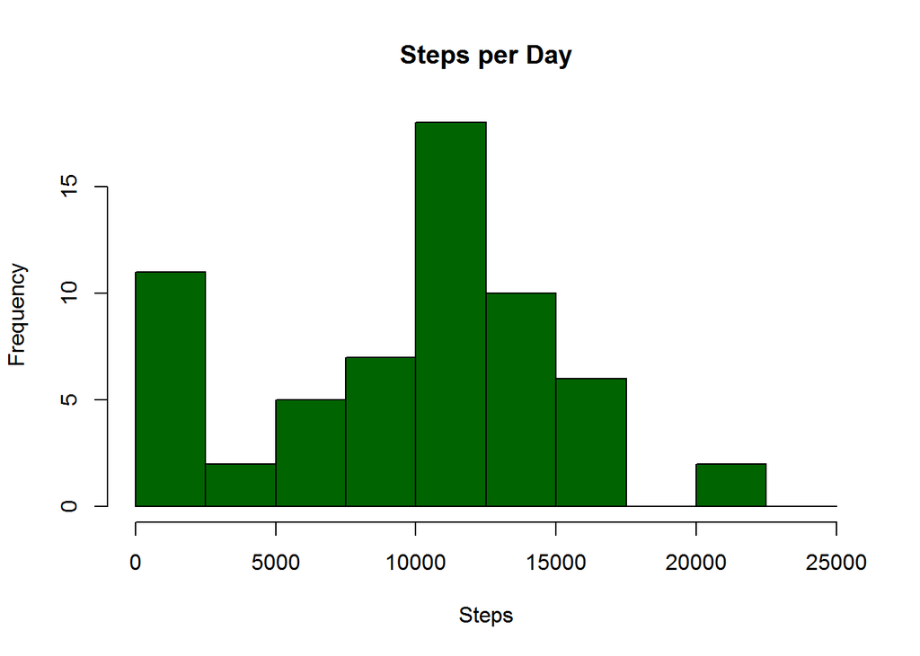

```r
hist(stepsperday$spd,col="dark green",xlab="Steps",main="Steps per Day",                breaks=seq(0,25000,2500))
```

```r
mean_stepsperday <- mean(stepsperday$spd,na.rm = TRUE)
mean_stepsperday
```

```
## [1] 9354.23
```

```r
median_stepsperday <- median(stepsperday$spd,na.rm = TRUE)
median_stepsperday
```

```
## [1] 10395
```

The mean steps per day is in the variable **mean_stepsperday**.  
The median steps per day is in the variable **median_stepsperday**.

## What is the average daily activity pattern?

1. Make a time series plot (i.e. type = “l”) of the 5-minute interval (x-axis) and the average number of steps taken, averaged across all days (y-axis)

```r
stepsperinterval <-  data %>% group_by(interval) %>%
        summarise(spi = mean(steps,na.rm = TRUE))
```

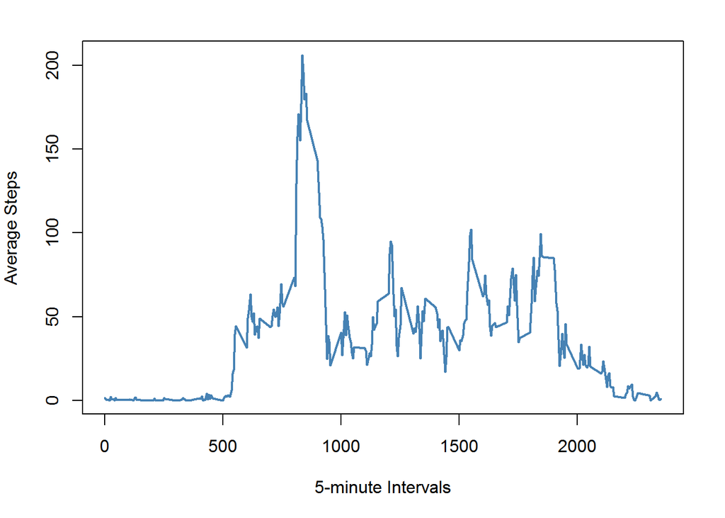

```r
par(mfrow=c(1,1),mar=c(5,4,2,2))
plot(stepsperinterval$interval, stepsperinterval$spi,type="l", col="steel blue",
     ylab="Average Steps",xlab="5-minute Intervals",lwd=2)
```

2. Which 5-minute interval, on average across all the days in the dataset, contains the maximum number of steps?

```r
stepsperinterval_max <- stepsperinterval[which.max(stepsperinterval$spi),1]
stepsperinterval_max
```

```
## # A tibble: 1 x 1
##   interval
##      <int>
## 1      835
```

The 5-minute interval accross all the days containing the maximum number of steps is stored in variable **stepsperinterval_max**.